# Report diagnostics

# Purpose

To produce a set of diagnostic plots that will be included in the report. Please note that these plots are just meant to provide an example of what could be created and how. They are not an exhaustive list of every possible plot and were chosen with the project aims in mind.

While this *should* give users examples of plots generated with the most up-to-date packages and methods, we’re always happy to have feedback. If you know of more efficient methods or want to suggest alternative ways of plotting the figures please open an issue with the details.

# Set up

### Model location

Define `modelName` and path to the model directory (`MODEL_DIR`).

```r
# Set directories for bbr models ----------------------------
# must go up an additional directory here as this script is located within the
# diagnostics-templates directory
MODEL_DIR <- params$modelDir
modelName <- params$run
thisModelPath <- file.path(MODEL_DIR, modelName)
```

### Figure location

If saving figures out to pdf, define where those pdfs should be saved to. Here the figures are saved to `deliv > figure > model_run_number`

```r
thisFigDir <- file.path(figDir, modelName)
if(!file.exists(thisFigDir)) dir.create(thisFigDir)

### set mrggsave figure directory here and tell R whether you want the pdf,
## the png or both (e.g.,  mrggsave.dev = "pdf,png")
options(mrggsave.dir = thisFigDir, mrggsave.dev = "pdf")
```

# Model details - Run number 100

```r
mod <- read_model(here::here(thisModelPath))
mod
```

── Status ─────────────────────────────────

• Finished Running

── Absolute Model Path ───────────────────────────

• /data/bbr-nonmem-poppk-foce/model/pk/100

── YAML & Model Files ───────────────────────────

• /data/bbr-nonmem-poppk-foce/model/pk/100.yaml

• /data/bbr-nonmem-poppk-foce/model/pk/100.ctl

── Tags ──────────────────────────────────

• one-compartment + absorption

• ETA-CL

• ETA-KA

• ETA-V

• proportional RUV

── Notes ──────────────────────────────────

• 1: systematic bias, explore alternate compartmental structure

```r
sum <- mod %>% model_summary()
sum
```

Dataset: ../../../data/derived/pk.csv

Records: 4292 Observations: 3142 Subjects: 160

Objective Function Value (final est. method): 33502.965

Estimation Method(s):

– First Order Conditional Estimation with Interaction

**Heuristic Problem(s) Detected:**

– parameter_near_boundary

– hessian_reset

– has_final_zero_gradient

| parameter_names | estimate | stderr | shrinkage |
| --- | --- | --- | --- |
| THETA1 | 1.40 |  |  |
| THETA2 | 4.56 |  |  |
| THETA3 | 1.04 |  |  |
| OMEGA(1,1) | 0.0574 |  | 3.15 |
| OMEGA(2,2) | 0.0855 |  | 4.28 |
| OMEGA(3,3) | 0.173 |  | 1.16 |
| SIGMA(1,1) | 0.0882 |  | 4.09 |

# Load Spec

The aim is to use the information in the spec file to label the figures automatically.

```r
# Tell R where to find the yml
specLo <- here::here("data", "derived", params$yspec)

# load in the spec file
spec <- ys_load(specLo) %>% ys_namespace("plot")
```

# Read in data

Read in the model details using `read_model`. Details stored in the `mod` object can be used to identify the location of the source data (used in $DATA) - to see how this is done look at the `bbr::get_data_path()` and `bbr::build_path_from_model()` helper functions.

After reading in the nonmem dataset and the output dataset they’re joined by a `NUM` column. **This assumes that a row number column (called `NUM`) was included during data assembly.** The idea here is that in NONMEM, you table just `NUM` and none of the other input data items. They all will get joined back to the nonmem output … even character columns.

The `data` used in the diagnostic plots has been filtered to only include the observations (i.e. `EVID==0`). Note that further modifications maybe needed, for example, if BLQ data was included in the model or if the `DV` was log-transformed. The dataset also converts the categorical covariates of interest to factors using the `yspec_add_factors` function and details described in the spec file.

The `id` subset gets the first record per ID. This would usually be the baseline value but consider filtering on a baseline flag if available. Also, if the model includes inter-occassion variaibility (IOV), the occassion variable should be included within the `distinct` function.

```r
# Read in model
mod <- read_model(here::here(thisModelPath))

# This can now be done with bbr::nm_join()
# # Read in nonmem dataset - pk.csv
# nm <- data.table::fread(file=bbr::get_data_path(mod), na.strings='.') %>% select(-DV)
# # Read in table from nonmem run
# tab <- mrgmisc::read_nonmem(bbr::build_path_from_model(mod, ".tab"))
# # join tab and nm using NUM
# data0 <- left_join(tab, nm,  by="NUM")

# Get original dataset and nonmem output
data0 <- nm_join(mod)

# filter to observation rows only
data <- data0 %>%
  filter(EVID==0) %>%
  yspec_add_factors(spec, STUDY, CP, RF, DOSE,
                    .suffix = "")
# filter to single row per ID and include factors
id <- distinct(data, ID, .keep_all=TRUE)
```

# General diagnostic plots

The following plots assume that the preferred x-axis labels are defined here.

```r
### Ideally get units from yaml
xTIME <- glue(pm_axis_time(), xunit = parens(spec$TIME$unit))
xTAD <- glue(pm_axis_tad(), xunit = parens(spec$TAD$unit))
xPRED <-  glue(pm_axis_pred(), xname = params$drugNameUnits)
```

## DV vs PRED and IPRED

Create plots of DV vs PRED and IPRED for the full dataset and stratified by renal function and hepatic function.

```r
dvp <- dv_pred(data, yname = params$drugNameUnits)      # DV vs PRED
dvip <- dv_ipred(data, yname = params$drugNameUnits)   # DV vs IPRED

p <- dvp / dvip

# DV vs PRED by renal function
dvp_rf <-  dv_pred(data, yname = params$drugNameUnits, scales="free") +
  facet_wrap(~RF, scales="free") + margin
# DV vs IPRED by renal function
dvip_rf <- dv_ipred(data, yname = params$drugNameUnits, scales="free") +
  facet_wrap(~RF, scales="free") + margin

# DV vs PRED by hepatic function
dvp_cp <- dv_pred(data, yname = params$drugNameUnits, scales="free") +
  facet_wrap(~CP, scales="free") + margin
# DV vs IPRED by hepatic function
dvip_cp <- dv_ipred(data, yname = params$drugNameUnits, scales="free") +
  facet_wrap(~CP, scales="free") + margin
```

```
## [1] "DV vs PRED and IPRED"
```

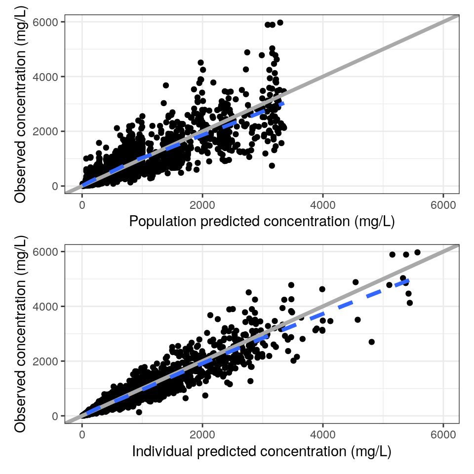

```
## [1] "DV vs PRED and IPRED by renal function"
```

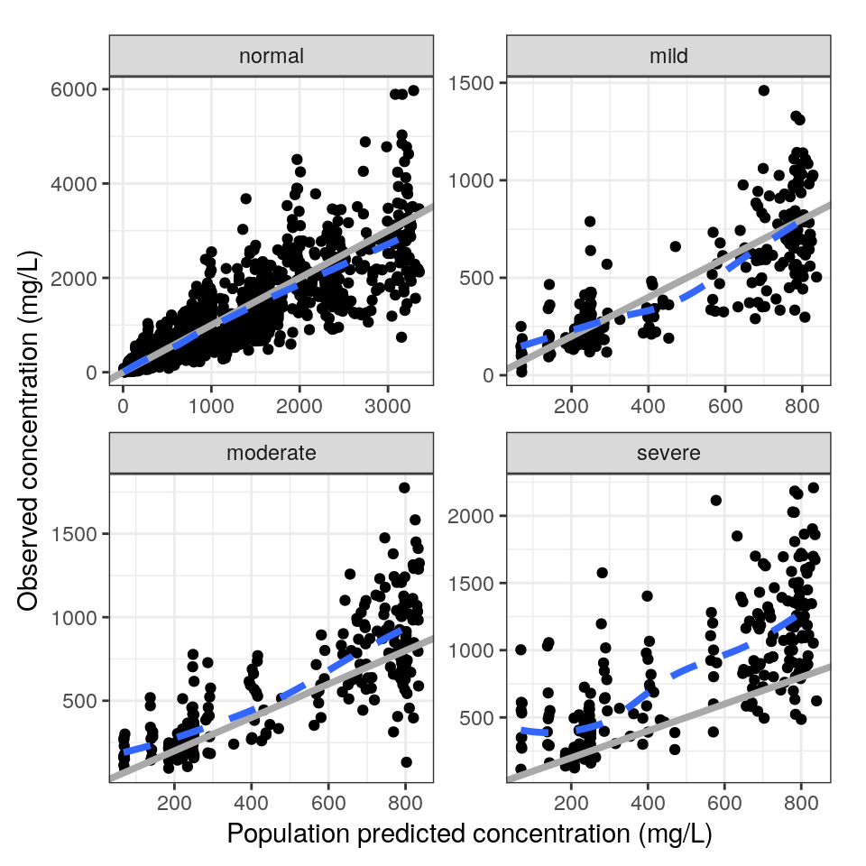

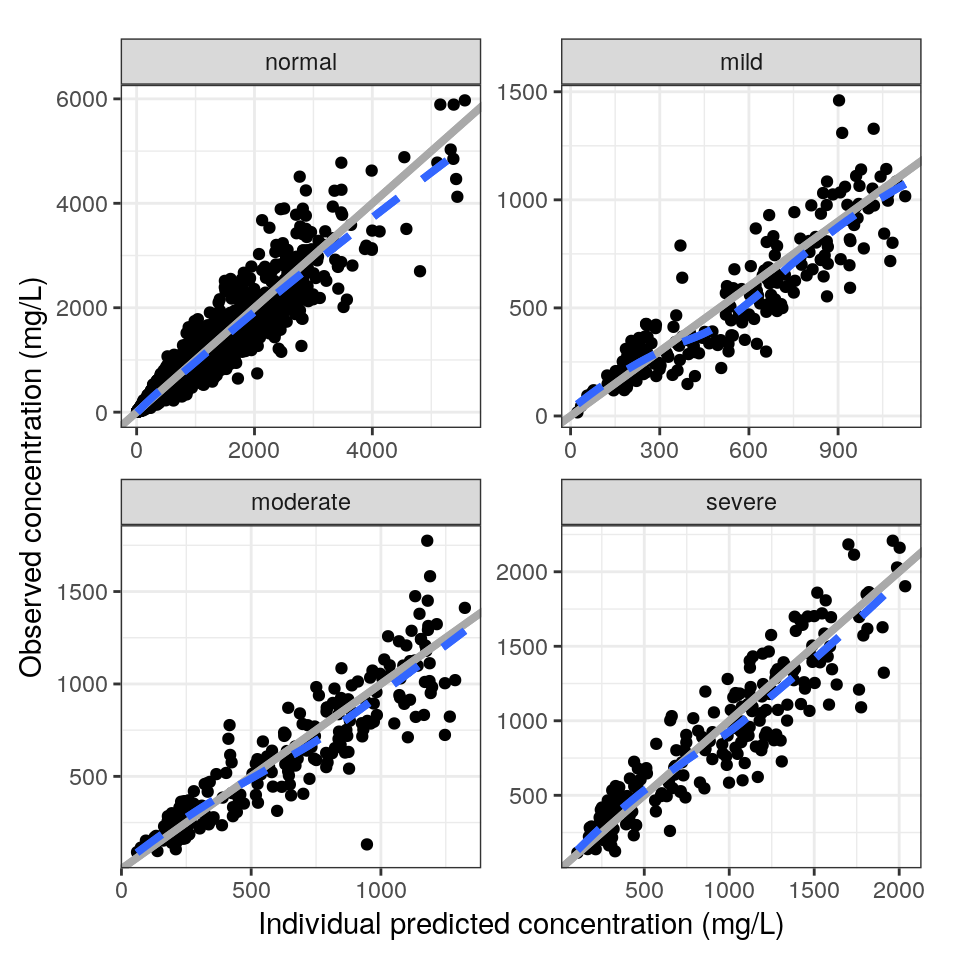

```
## [1] "DV vs PRED and by hepatic function"
```

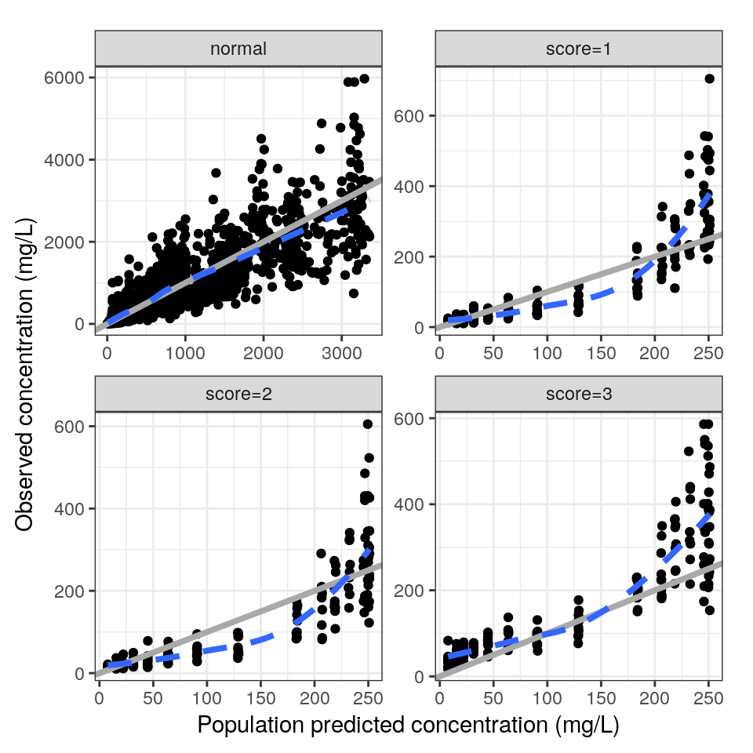

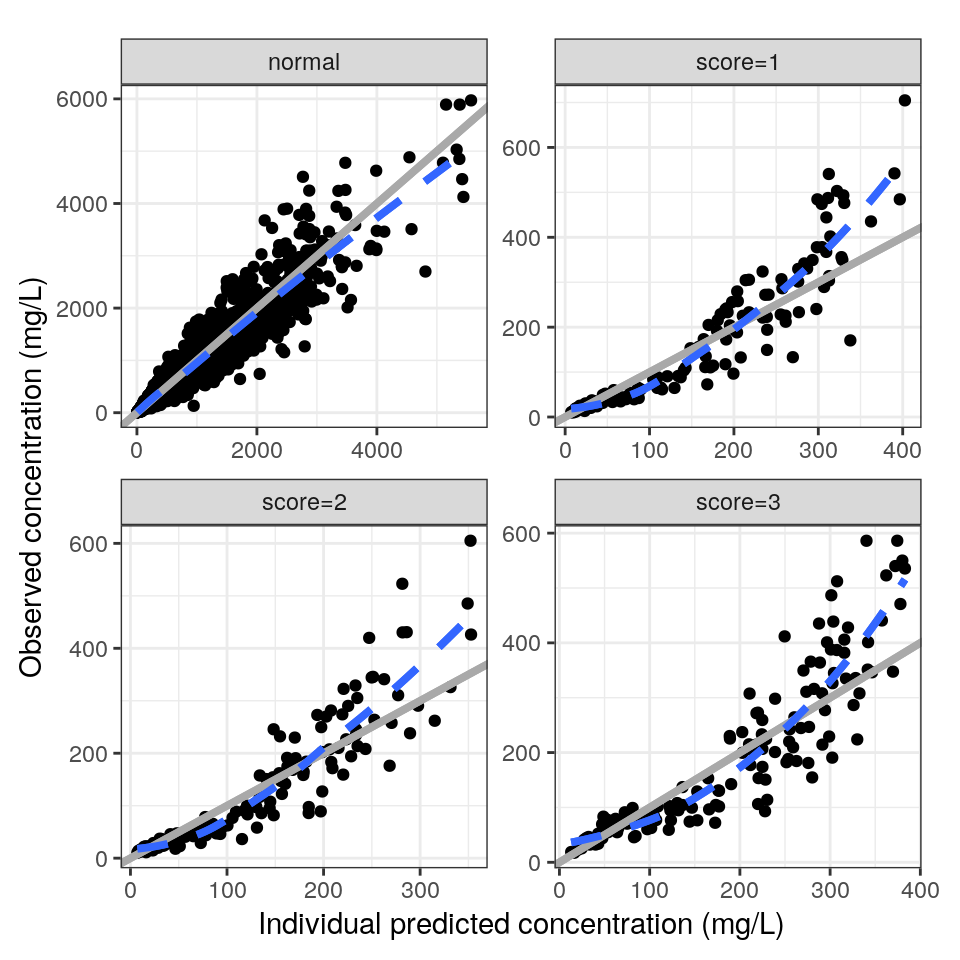

## NPDE plots

NPDE vs PRED, time and time after dose.

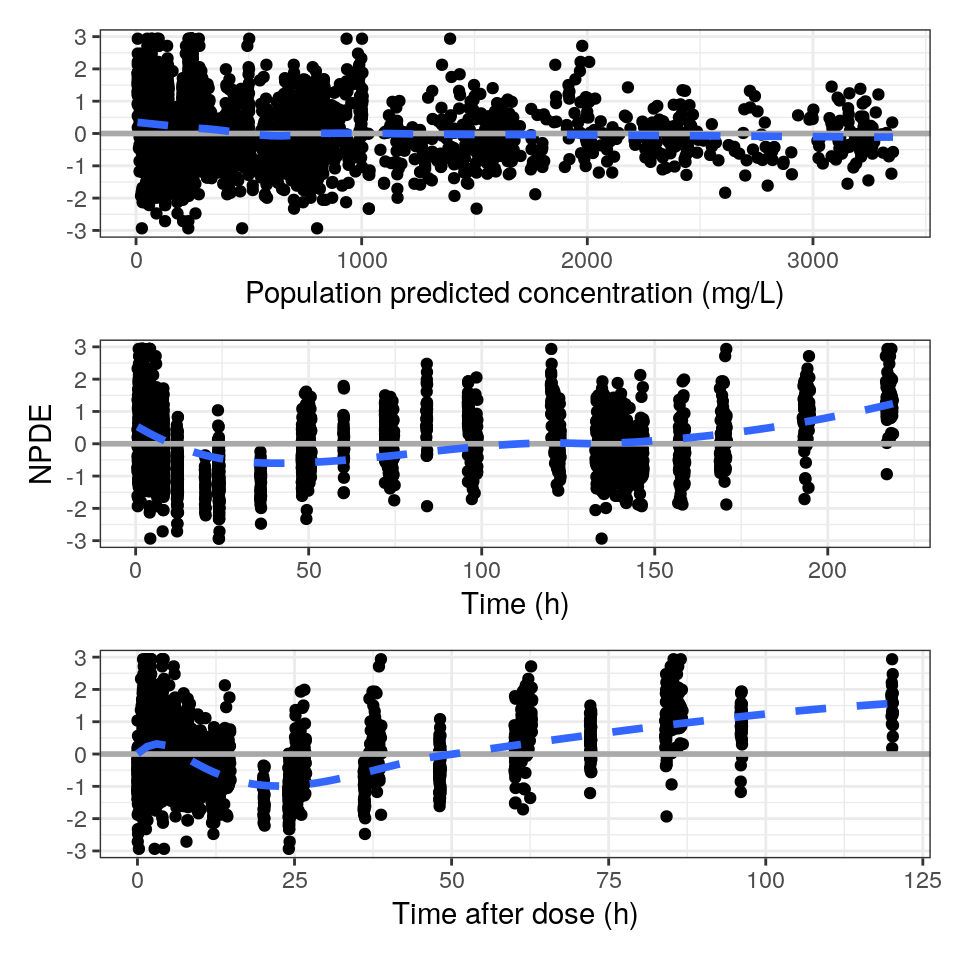

```r
##' Plan to display these three plots in a single, 3 panel figure and so the y-axis
##' labels are removed manually for display purposes
p1 <- npde_pred(data, x = xPRED, y = "NPDE //  ")
p2 <- npde_time(data, x = xTIME)
p3 <- npde_tad(data, x = xTAD, y = "NPDE //  ")

p <- p1 / p2 / p3
```

NPDE vs continuous covariates

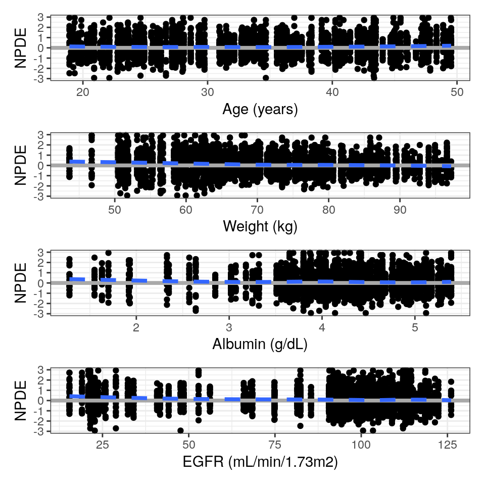

```r
NPDEco <- spec %>%
  ys_select(params$contCov) %>%      # select the covariates of interest
  axis_col_labs(title_case = TRUE,   # converts yspec short to title_case
                short_max = 10) %>%  # if yspec short is >10 characters it keeps the abbreviation
  as.list()

pList = purrr::map(NPDEco, ~ npde_cont(data, x = .x))
p = pList$AGE / pList$WT / pList$ALB / pList$EGFR
```

NPDE vs categorical covariates.

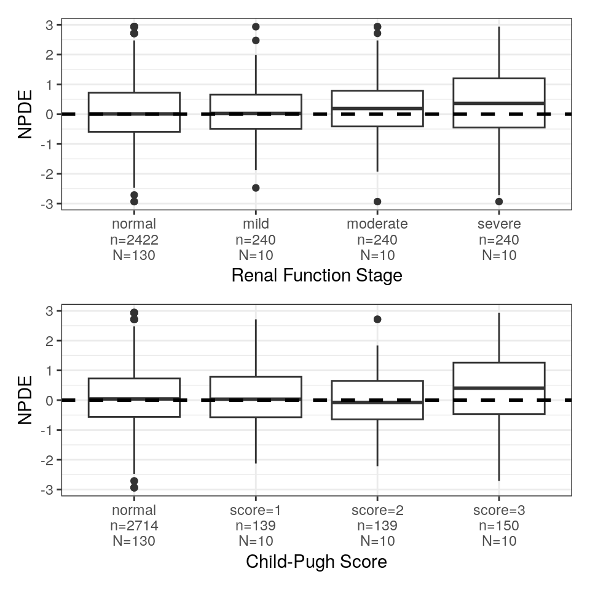

```r
NPDEca <- spec %>%
  ys_select("RF", "CP") %>%             # select the covariates of interest
  # ys_select(params$catCov) %>%        # this can be passed in params
  axis_col_labs(title_case = TRUE) %>%  # converts yspec short to title_case
  as.list()


pList = purrr::map(NPDEca, ~ npde_cat(data, x = .x))
p = pList$RF / pList$CP
```

## NPDE density histogram

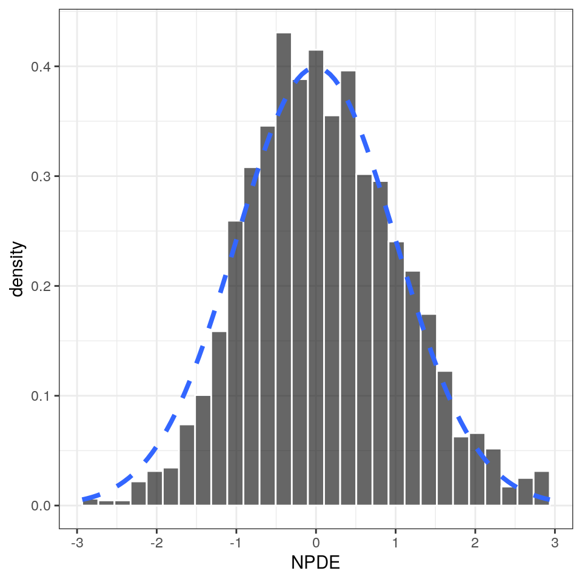

```r
p <- npde_hist(data)
```

## CWRES vs PRED, time and time after dose

```r
p1 <- cwres_pred(data, x = xPRED, y = "CWRES //  ")
p2 <- cwres_time(data, x = xTIME)
p3 <- cwres_tad(data, x = xTAD, y = "CWRES //  ")

p = p1 / p2 / p3
```

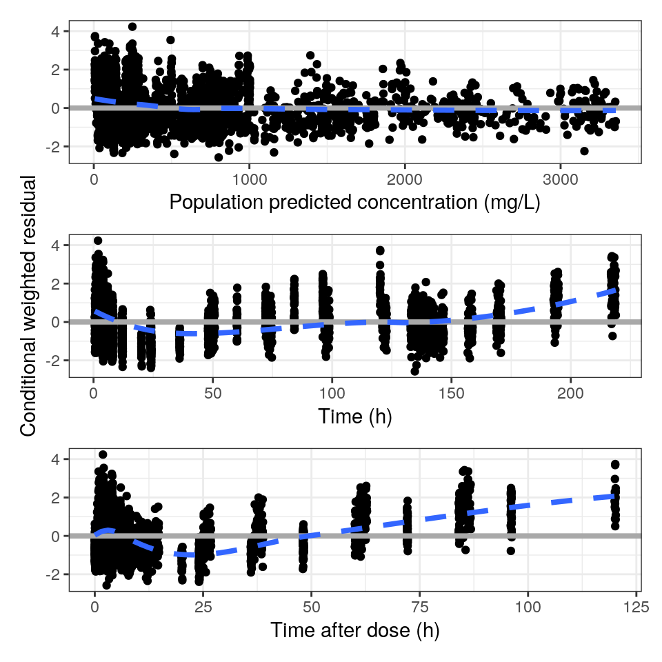

## CWRES qq and density plot

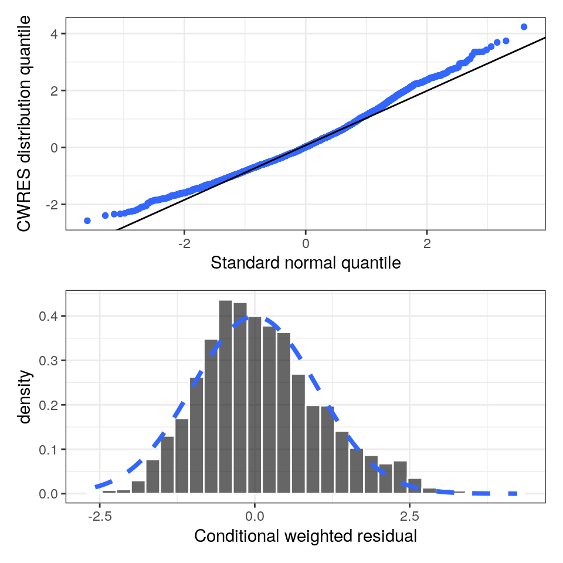

```r
# using patchwork to combine plots
p <- cwres_q(data) / cwres_hist(data)
```

# EBEs-based diagnostics

## ETA pairs plot

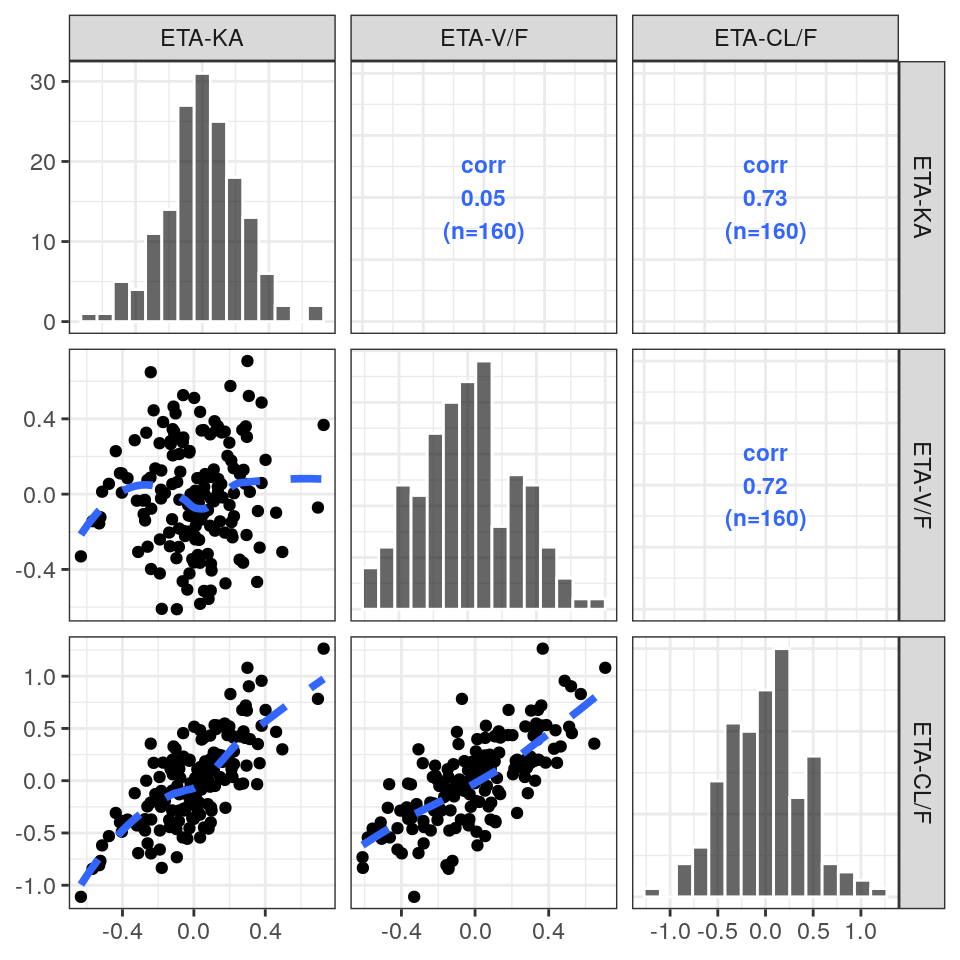

```r
p <- eta_pairs(id, params$etas)
```

## Continuous covariate plots

These plots uses the yspec to automatically rename the axis labels.

```r
co <- spec %>%
  ys_select(params$contCov) %>%     # select the covariates of interest
  axis_col_labs(title_case = TRUE,  # converts yspec short to title_case
                short_max = 10)     # if yspec short is >10 characters it keeps the abbreviation
```

### ETA vs continous covariates

Note that here we use a function that maps over the ETAs (not the covariates) because the purpose of these plots was to determine whether there were any trends in the covariates for a given ETA. This may need to be edited to address different study specific questions

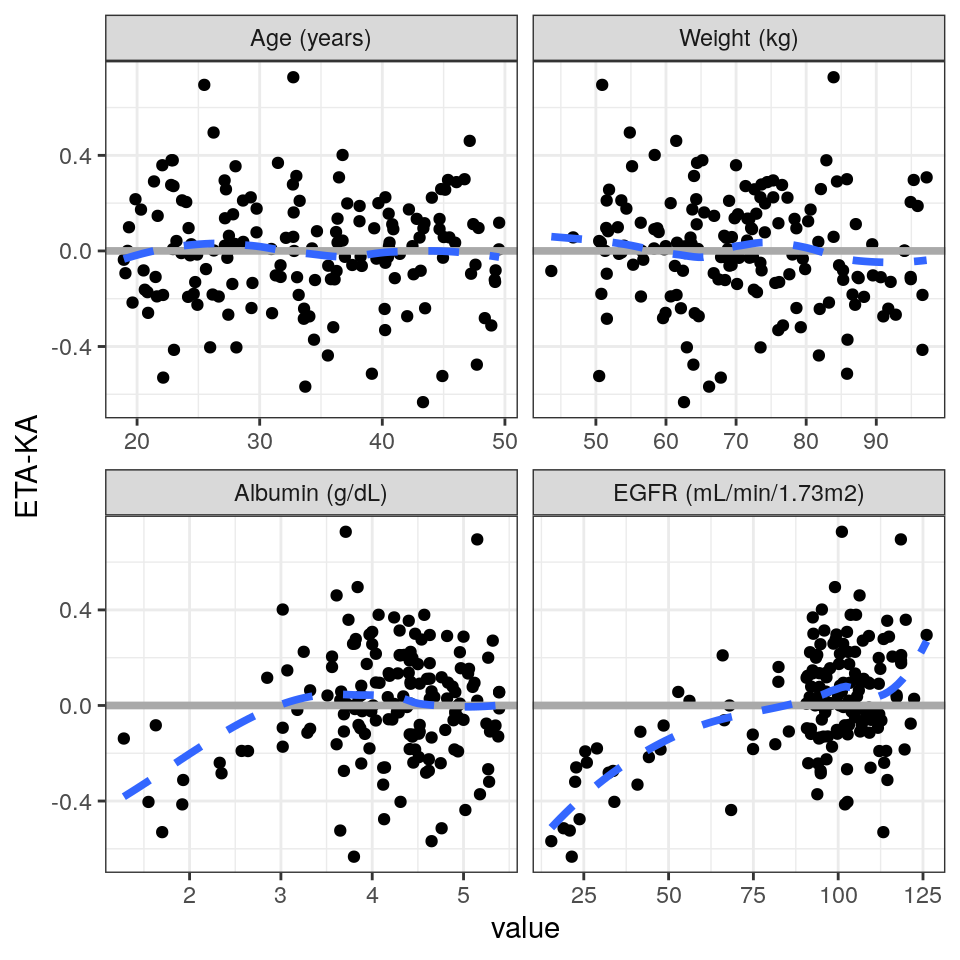

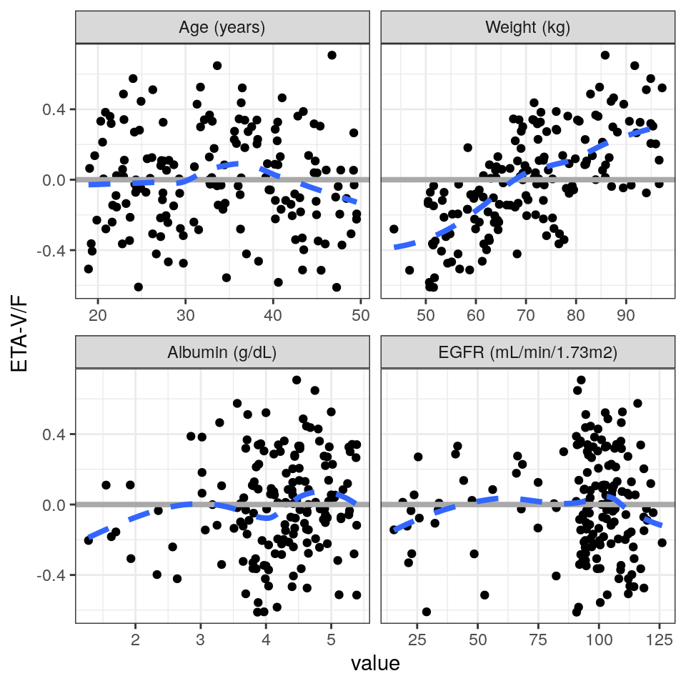

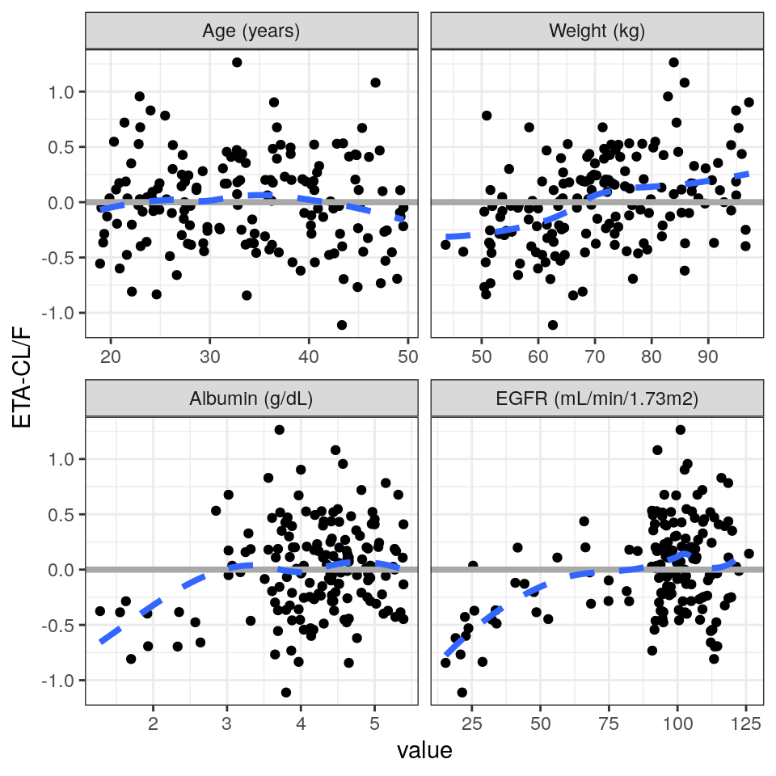

```r
p <- purrr::map(.x = params$etas, ~ map_wrap_eta_cont(.x, co, id))
```

### Continous covariate pairs plot

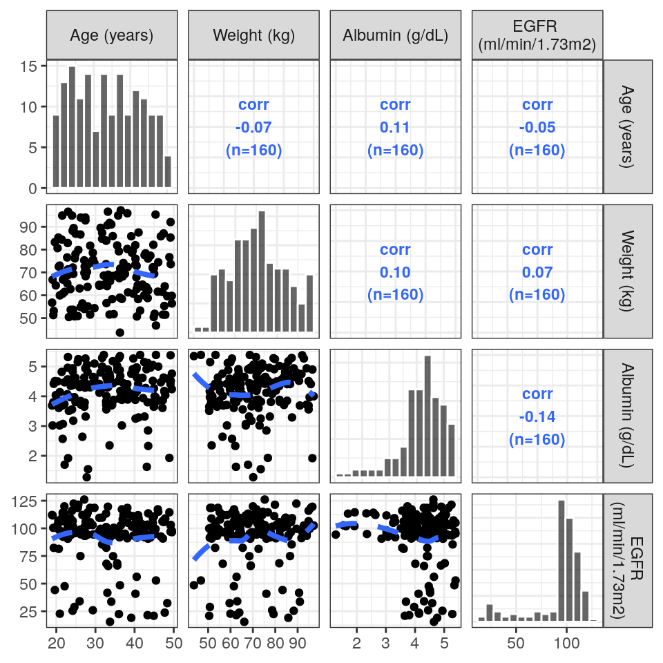

```r
# need to manually force units onto a new line for EGFR here to fit label in the panel
co2 <- co
if("EGFR" %in% params$contCov){
  co2["EGFR"] = "EGFR//EGFR \n(ml/min/1.73m2)"
}
p <- eta_pairs(id, co2)
```

## Categorical covariate plots

These plots uses the yspec to automatically rename the axis labels.

```r
ca <- spec %>%
  ys_select(params$catCov) %>%   # select the covariates of interest
  axis_col_labs(title_case=TRUE)  # converts yspec short to title_case
```

### ETA vs categorical covariates

Note that here we use a function that maps over the covariates (not the ETAs) because the purpose of these plots was to determine whether there is any difference in the distribution of ETAs across studies, dosing groups and disease states. This should be updated to reflect the questions you’re trying to address.

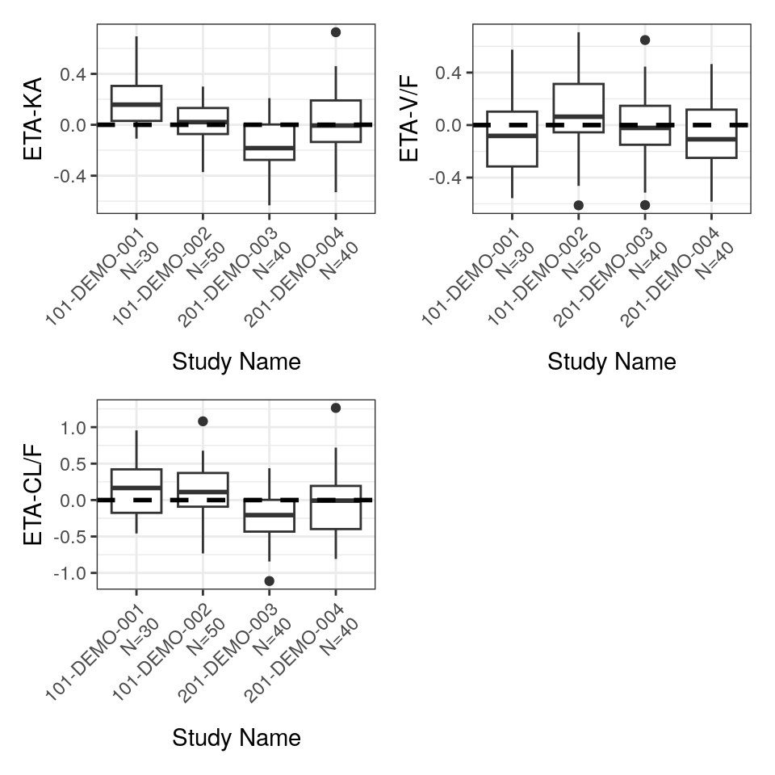

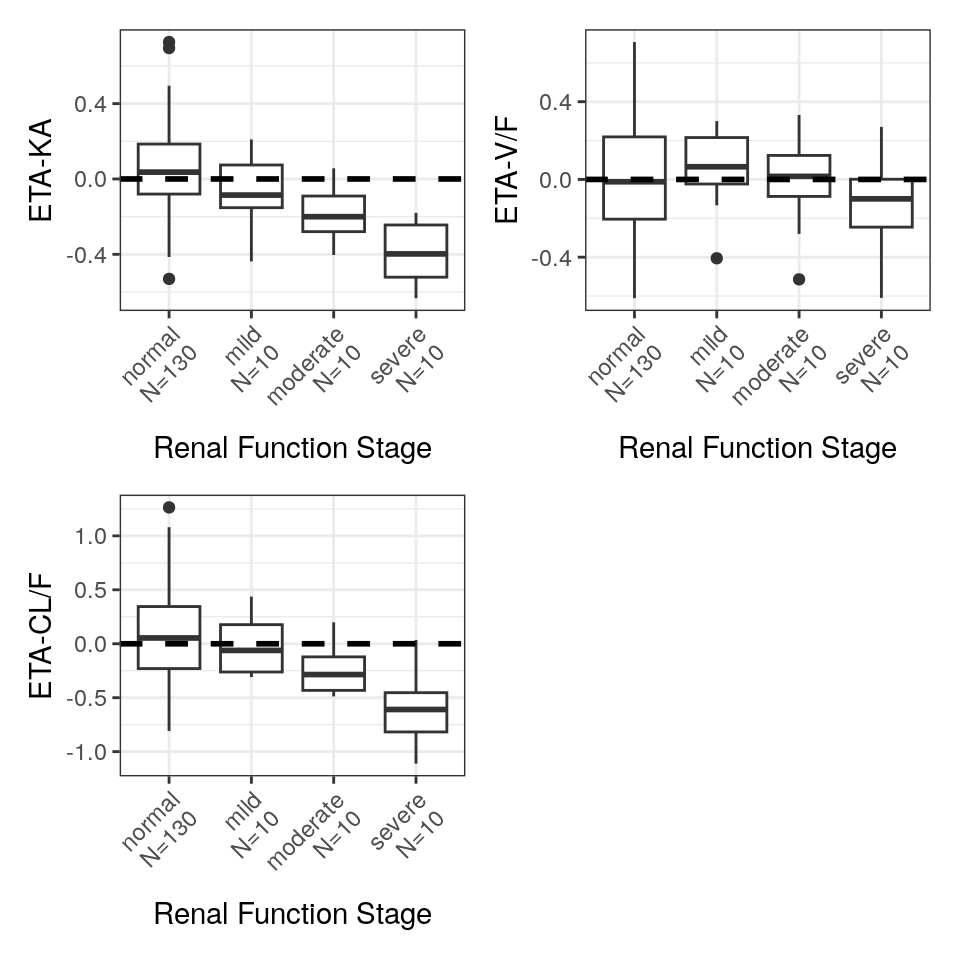

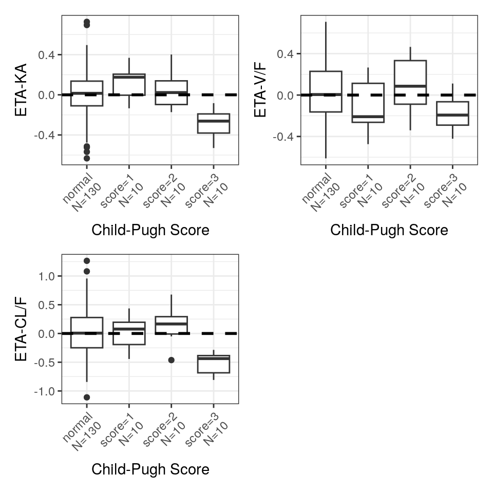

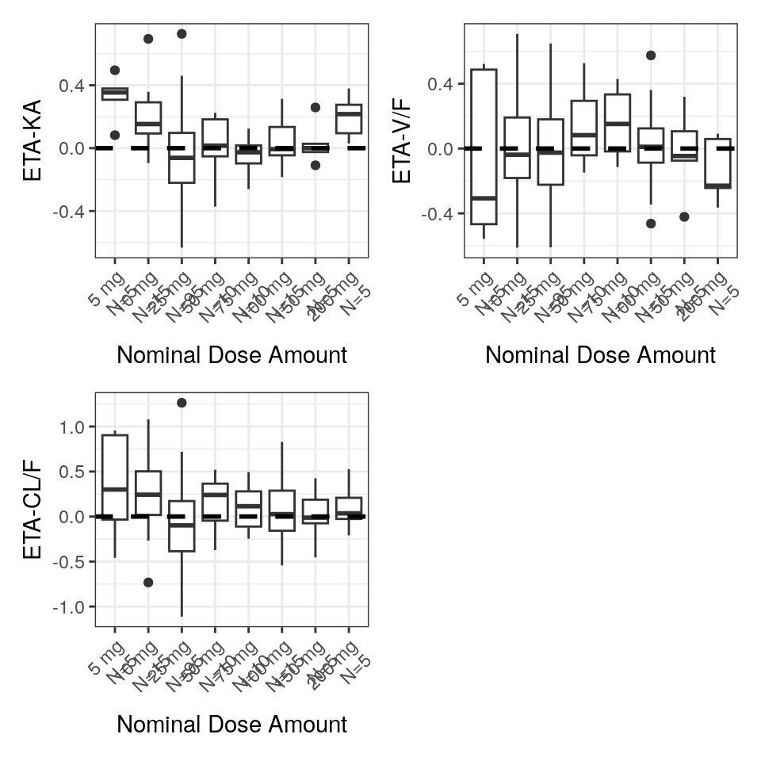

```r
if (length(params$etas) > 1) {
  p <- purrr::map(.x = ca, ~ map_eta_cat(.x, params$etas, id))
} else {
  ## CHECK: depending on the labels, this may need to be changed
  p <- purrr::map(.x = ca, ~ eta_cat(id, .x, params$etas) + rot_x(45))
}
```

# Session details

It is considered good practice to include these details at the end of all rmd scripts

```r
Sys.getenv("AMI_NAME")
```

```
## [1] ""
```

```r
bbr::bbi_version()
```

```
## [1] "3.3.0"
```